# NCDOT Bike Crash Data: Locality Type and Frequency Over Time

Jed Higdon

1/30/2020

##NCDOT Bike Crash Data Time Plotting

This is a tutorial for working with NCDOT bike crash data to plot change over time using RStudio.

First, we need to import the data.

```r
#Locate the file on your computer and name it something. We've chosen to name it "the_file"
the_file <- "C:/Users/jed/Documents/School/Senior/Spring/GEOG 456/bikecrash.csv"

#Next, open the .csv using the following line
df <- read.csv(the_file)

#head(df) will allow us to view the column names and first 6 rows of the data frame we opened
head(df)
```

|  | ï..X | Y | OBJECTID | AmbulanceR | BikeAge | BikeAgeGrp | BikeAlcDrg | BikeAlcFlg | BikeDir | BikeInjury | BikePos | BikeRace | BikeSex | City | County | CrashAlcoh | CrashDay | CrashGrp | CrashHour | CrashLoc | CrashMonth | CrashSevr | CrashType | CrashYear | Developmen | DrvrAge | DrvrAgeGrp | DrvrAlcDrg | DrvrAlcFlg | … |
| --- | --- | --- | --- | --- | --- | --- | --- | --- | --- | --- | --- | --- | --- | --- | --- | --- | --- | --- | --- | --- | --- | --- | --- | --- | --- | --- | --- | --- | --- | --- |
| 1 | -79.79401 | 36.07553 | 1001 | Yes | 51 | 50-59 | . | No | With Traffic | B: Suspected Minor Injury | Travel Lane | White | Male | Greensboro | Guilford | No | Friday | Loss of Control / Turning Error | 18 | Intersection-Related | December | B: Suspected Minor Injury | Motorist Turning Error - Right Turn | 2007 | Commercial | 49 | 40-49 | . | No | … |
| 2 | -78.87798 | 35.05250 | 1002 | Yes | 50 | 50-59 | . | No | Facing Traffic | C: Possible Injury | Unknown | Black | Male | Fayetteville | Cumberland | No | Monday | Motorist Failed to Yield - Sign-Controlled Intersection | 17 | Intersection | December | C: Possible Injury | Motorist Drive Out - Sign-Controlled Intersection | 2007 | Commercial | 33 | 30-39 | . | No | … |
| 3 | -79.21143 | 34.73131 | 1003 | No | 63 | 60-69 | . | No | With Traffic | C: Possible Injury | Travel Lane | Native American | Male | None - Rural Crash | Robeson | No | Monday | Motorist Overtaking Bicyclist | 18 | Non-Intersection | December | C: Possible Injury | Motorist Overtaking - Other / Unknown | 2007 | Farms, Woods, Pastures | 999 | Unknown | . | No | … |
| 4 | -79.70355 | 34.89595 | 1004 | Yes | 53 | 50-59 | . | No | With Traffic | C: Possible Injury | Bike Lane / Paved Shoulder | Black | Male | Hamlet | Richmond | No | Monday | Motorist Overtaking Bicyclist | 1 | Non-Intersection | December | C: Possible Injury | Motorist Overtaking - Undetected Bicyclist | 2007 | Residential | 65 | 60-69 | . | No | … |
| 5 | -80.76864 | 35.80956 | 1005 | No | 14 | 15-Nov | . | No | With Traffic | C: Possible Injury | Travel Lane | Black | Male | None - Rural Crash | Iredell | No | Tuesday | Loss of Control / Turning Error | 15 | Non-Intersection | December | C: Possible Injury | Bicyclist Lost Control - Other / Unknown | 2007 | Farms, Woods, Pastures | 44 | 40-49 | . | No | … |
| 6 | -78.90074 | 35.94424 | 1006 | Yes | 38 | 30-39 | . | No | With Traffic | B: Suspected Minor Injury | Travel Lane | Black | Male | Durham | Durham | No | Tuesday | Motorist Right Turn / Merge | 7 | Intersection | March | B: Suspected Minor Injury | Motorist Right Turn - Same Direction | 2008 | Residential | 21 | 20-24 | . | No | … |

Packages are groups of opensource code that can be used within R. We need to download a few before moving forward.

```r
#There are a number of packages we will need to make sure we have downloaded before creating our
#visualizations. The lines below will install the packages we need and open their libraries.
#install.packages("ggplot2")
#install.packages("RColorBrewer")
#install.packages("tidyverse")
library(ggplot2)
library(RColorBrewer)
library(tidyverse)
```

Now, let’s get to the temporal analyses. We can start by choosing the Locality Type variable to measure its change over time.

Next, we want to create a variable that counts the number of crashes that occur in each Locality type so we are able to analyze it. The code below will create a variable called “monthly_count” that will do this by each month.

```r
monthly_count <- df %>%
  count(CrashMonth, Locality)
```

Now lets plot the data. Our data is monthly_count, and we are going to put the CrashMonth on the x-axis and the number of crashes (n) on the y-axis. Grouping by Locality will separate our lines based on the Locality variable, and color = Locality will give each line a different color. The final part of the code, geom_line(), tells R to display our data as lines.

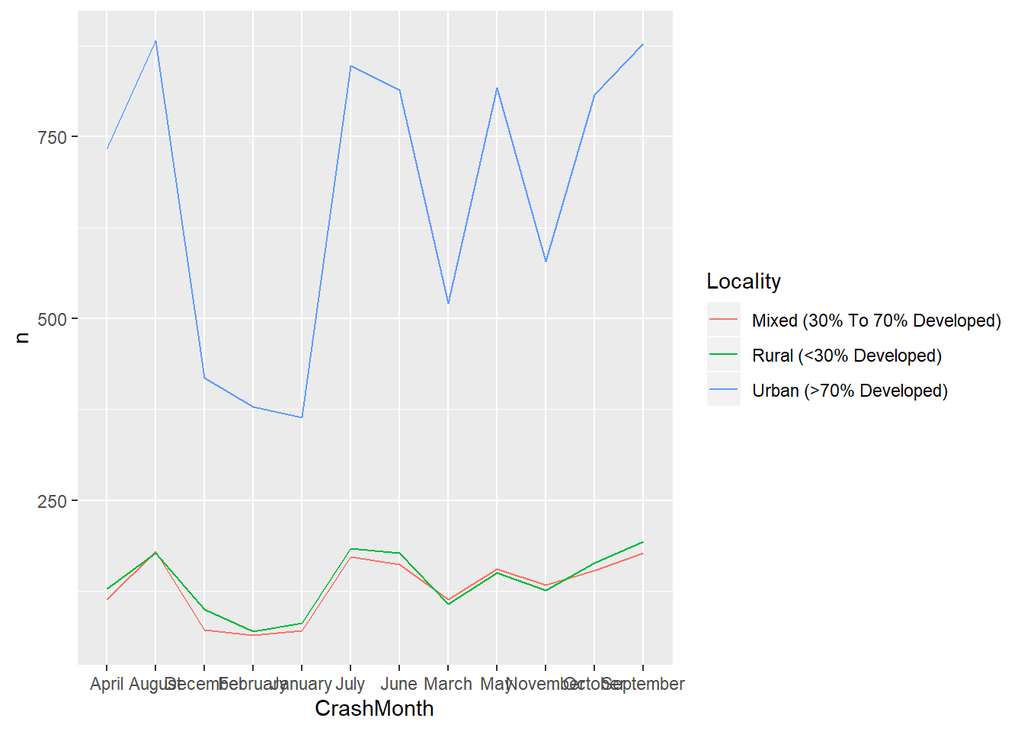

```r
ggplot(data = monthly_count, mapping = aes(x = CrashMonth, y = n, group = Locality, color = Locality)) +
       geom_line()
```

This output looks good, but it isn’t all that interesting. We might be able to learn more about when people crash if we display the data by hour rather than by month. Let’s create a variable called hourly_count that does the same thing as monthly_count, but for every hour.

```r
hourly_count <- df %>%
  count(CrashHour, Locality)
```

Now let’s plot it again, but this time using hourly_count as our data.

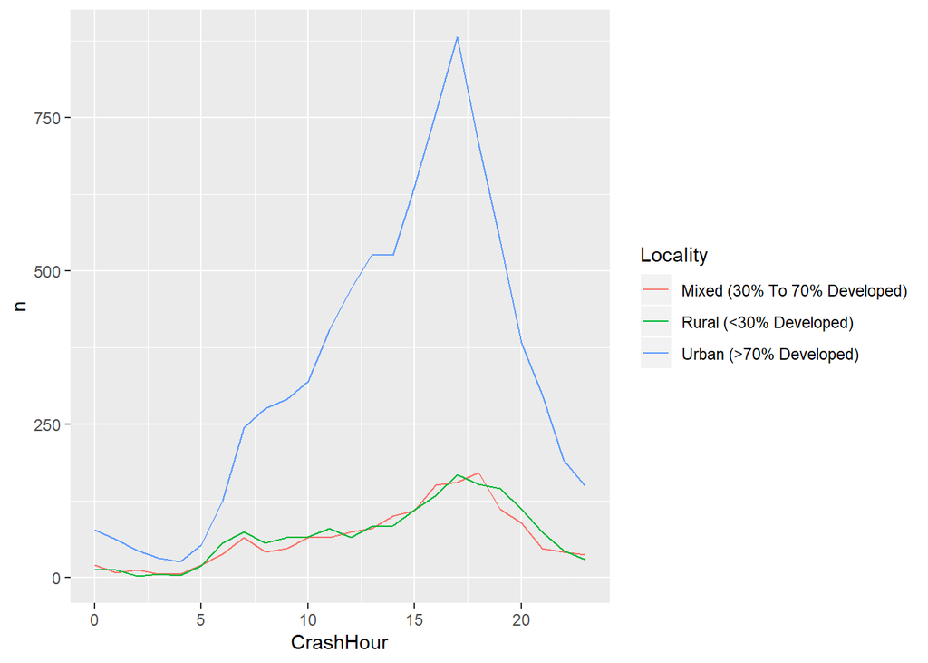

```r
ggplot(data = hourly_count, mapping = aes(x = CrashHour, y = n, group = Locality, color = Locality)) +
  geom_line()
```

Now we’re getting somewhere. We can see that there are many more crashes in urbanized areas, and the rate of crash increase is also much higher during rush hour in urbanized areas. Let’s try to make our output easier to look at. Using the labs function, we can add a title as well as x- and y-axis labels. The theme_bw() function changes our chart from the default style to one that is more aesthetically pleasing. We can also change the relative size, color, and orientation of axis text using the theme() function as outlined below.

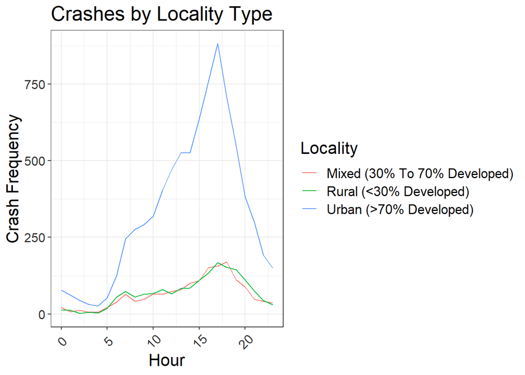

```r
ggplot(data = hourly_count, mapping = aes(x = CrashHour, y = n, group = Locality, color = Locality)) +
  geom_line() +
  labs(title = "Crashes by Locality Type",
       x = "Hour",
       y = "Crash Frequency") +
  theme_bw() +
  theme(axis.text.x = element_text(colour = "grey20", size = 12, angle = 45, hjust = 0.5, vjust = 0.5),
        axis.text.y = element_text(colour = "grey20", size = 12),
        text = element_text(size = 16))
```

This final output is useful for analysis and tells us a story about the data and how Locality type crash frequency changes throughout the day.